# GİP İşlem Akışı

Berk Orbay (Algopoly)

2020-03-26

Bu dökümanın kapsamı EPİAŞ Şeffaflık Platformu’ndaki Gün İçi Piyasası (GİP) İşlem Akışı verisinin csv formatında indirdikten sonra, dosyanın analiz yapılabilir şekilde içeriye alınması, veri formatlarının düzenlenmesi ve kısa bir iki keşifsel analiz yapılmasını içermektedir. Tamamen eğitim amaçlı olup veri EPİAŞ Şeffaflık Platformu üzerinden sağlanmaktadır.

GİP, elektriğin toptan ticaretinde gün içinde sürekli işlem yapılan bir piyasadır. GİP hakkında daha fazla bilgi almak için [EPİAŞ Gün İçi Piyasası Tanıtımı](https://www.epias.com.tr/gun-ici-piyasasi/giris/)’nı okuyabilir veya [Gün İçi Piyasası Eğitimi](https://www.youtube.com/watch?v=l6fvfp277Zg)’ni izleyebilirsiniz.

# Hazırlık

1. Verinin indirilmesi

Ana veri kaynağı [EPİAŞ Şeffaflık Platformu GİP İşlem Akışı](https://seffaflik.epias.com.tr/transparency/piyasalar/gip/islem-akisi.xhtml) sayfasıdır. Burada istediğiniz tarih aralığını seçip sağ alt köşedeki ikonlardan csv’yi seçerek indirebilirsiniz.

Bu dökümanda kullanılan veri setini ise [BURADAN](https://github.com/acikenerji/data/blob/master/GipIslemAkisi-27022020-25032020.csv?raw=true) indirebilirsiniz. Bu dökümandaki analizler için 27 Şubat - 25 Mart 2020 tarihleri arasındaki işlem akışı verisini kullanıyoruz.

2. Gerekli paketlerin yüklenmesi

Verinin içeriye alınıp düzenlenmesi ve analiz edilebilmesi için aşağıdaki kodun çalıştırılması yeterlidir.

```r
pti <- c("dplyr","ggplot2","lubridate","readr","stringr") # gereken paketler
pti <- pti[!(pti %in% installed.packages())]
if(length(pti) > 0) install.packages(pti,repos="https://cran.r-project.org")
```

Not: Bir ihtimal `Error in library(PAKET_ISMI) : there is no package called ‘PAKET_ISMI’` gibi bir hata alabilirsiniz. Bu durumda paketi `install.packages("PAKET_ISMI",repos="https://cran.r-project.org")` yöntemiyle yüklemeniz gerekir.

# Verinin İçeriye Alınması ve Düzenlenmesi

Veriyi içeriye alırken `readr` paketinin `read_delim` fonksiyonunu kullanacağız. Önce verinin bulunduğu yeri tespit etmeniz gerekiyor. Tam dosya yolunu bilmiyorsanız `file.choose()` fonksiyonunu kullanabilirsiniz.

```r
data_path <- "GipIslemAkisi-27022020-25032020.csv"
```

```r
gip_raw <-
  readr::read_delim( #readr paketinin read_delim fonksiyonu
    data_path, #verinin bulunduğu konum
    delim = ",", #csv verisinin ayraç karakteri... genelde virgül veya noktalı virgül (;) olur
    col_types = "Dtcnn", #sütun veri tipleri D (tarih), t (zaman), c (karakter/string), n (numerik)
    locale = # veri tiplerinin stillerini burada tanımlıyoruz
      readr::locale( # readr paketinin locale fonksiyonu ile veri stillerini tanımlayabiliyoruz
        date_format = "%d/%m/%Y", # tarih stili GG/AA/YYYY şeklinde ör. 26/03/2020
        time_format="%H:%M", # zaman stili SS:DD şeklinde ör. 01:00
        decimal_mark=",", # ondalık ayracı... csv dosyasında , ile ayrılıyor ama R'da işlem yaparken . olmalı
        grouping_mark=".", # binlik ayracı... csv dosyasında . ile ayrılıyor ama R'da işlem yaparken , olmalı
        tz="Turkey" # Saat dilimi (Türkiye UTC+3 içerisindedir)
      ),
    skip=1, # ilk satır sütun isimleri olduğu için satırı atlıyoruz
    col_names=c("date","hour","contract_id","price","lot") # sütun isimlerini kendimiz belirliyoruz
  )

head(gip_raw)
```

```
## # A tibble: 6 x 5
##   date       hour   contract_id   price   lot
##   <date>     <time> <chr>         <dbl> <dbl>
## 1 2020-02-27 00'00" PB20022702-01  157.    15
## 2 2020-02-27 00'00" PB20022702-01  155.    66
## 3 2020-02-27 00'00" PB20022702-01  160.     4
## 4 2020-02-27 00'00" PH20022702     161.     3
## 5 2020-02-27 00'00" PH20022702     162.     8
## 6 2020-02-27 01'00" PB20022709-01  326.    22
```

Elimizdeki ham veriyi kısaca açıklamak gerekirse; her satır işlemin ne zaman yapıldığı (tarih ve saat/dakika), kontrat ismi, uzlaşılan fiyat ve lot (0,1 MWh) cinsinden işlem büyüklüğünü içermektedir. Kontrat isimleri ise kontratın tipi (saatlik PH, blok PB), hangi günün hangi saati/saatleri (ör. 200227 - 27 Şubat 2020; 02 saat 02:00, 02-05 +5 saat blok -02:00 - 07:00 arası-) bilgilerini içermektedir.

Örneğin ilk satır; 27 Şubat 2020 tarihinde 00:00’da işlemi gerçekleşen PB20022702-01 kontratı üzerinde 27 Şubat 2020 tarihinde 02:00 ve 03:00 saatlerinin her biri için MWh fiyatı 157.24TL’den 15er lot (1.5MWh) alım-satım gerçekleştiğini ifade etmektedir. **Uyarı:** Kontrat isimleri tekil işlem isimleri değildir (ör. birden çok PB20022702-01 işlemi olabilir).

Daha sonra bu veriyi analiz yapabileceğimiz bir formata sokuyoruz. Genel olarak tarih ve zamanları düzenliyor; kontrat tiplerini, tarihlerini başlangıç ve bitiş zamanlarını çıkarıyor; ve, fiyat ve hacim bilgisini hesaplıyoruz. GİP’te hacim birimi Lot olarak belirlenmiştir ve 0,1 MWh’e denk gelmektedir. Analizlerimiz için bu değeri 10 ile bölerek MWh değerini alıyoruz.

```r
gip_wip <-
gip_raw %>% ## zincir operatörü (ing. pipe operator) pek çok R paketinde bulunan bir özelliktir
  transmute( ## veriyi düzenlemek için dplyr paketinin transmute fonksiyonunu kullanıyoruz
    #dt: tarih-zaman
    dt = lubridate::as_datetime(date,tz="Turkey") + lubridate::hours(lubridate::hour(hour)) + lubridate::minutes(lubridate::minute(hour)),
    #contract_id: kontrat ismi
    contract_id,
    #contract_type: kontrat türü (PB blok, PH saatlik)
    contract_type = substr(contract_id,1,2),
    #contract_date: kontratın geçerli olduğu tarih
    contract_date = readr::parse_date(substr(contract_id,3,8),format="%y%m%d"),
    #contract_start: kontratın başlangıç saati
    contract_start = readr::parse_integer(substr(contract_id,9,10)),
    #block_hours: blok kontrat ise kaç saati kapsadığı (saatlikse 0)
    block_hours = stringr::str_extract(contract_id,pattern="-[0-9][0-9]+$"),
    block_hours = ifelse(is.na(block_hours),0,as.integer(gsub("-","",block_hours))),
    #contract_end: kontratın bitiş saati
    contract_end = contract_start + block_hours,
    #price: kontrat fiyatı
    price,
    #volume: kontrat büyüklüğü (MWh)
    volume = lot/10
  )

head(gip_wip)
```

```
## # A tibble: 6 x 9
##   dt                  contract_id   contract_type contract_date
##   <dttm>              <chr>         <chr>         <date>
## 1 2020-02-27 03:00:00 PB20022702-01 PB            2020-02-27
## 2 2020-02-27 03:00:00 PB20022702-01 PB            2020-02-27
## 3 2020-02-27 03:00:00 PB20022702-01 PB            2020-02-27
## 4 2020-02-27 03:00:00 PH20022702    PH            2020-02-27
## 5 2020-02-27 03:00:00 PH20022702    PH            2020-02-27
## 6 2020-02-27 03:01:00 PB20022709-01 PB            2020-02-27
##   contract_start block_hours contract_end price volume
##            <int>       <dbl>        <dbl> <dbl>  <dbl>
## 1              2           1            3  157.    1.5
## 2              2           1            3  155.    6.6
## 3              2           1            3  160.    0.4
## 4              2           0            2  161.    0.3
## 5              2           0            2  162.    0.8
## 6              9           1           10  326.    2.2
```

# Analiz ve Görselleştirme

Örnek olması açısından görselleştirme içeren bir iki analizi aşağıda bulabilirsiniz.

## Kümülatif işlem hacmi

GİP işlem hacimlerinde dönem dönem değişiklik yaşanıp yaşanmadığını incelemek istiyoruz. Görsel olarak en iyi yöntemlerden biri kümülatif toplam işlem hacimlerini zamana karşı çizdirmektir. Hem blok/saatlik ayrı ayrı hem de toplam hacimleri bir grafikte gösterebiliriz. Not: İlgili veriyi hesaplarken blok hacimlerinin ilgili her saat için geçerli olmasını dolayısıyla verilen hacmin blok saat sayısı ile çarpılması gerektiğini hatırlamak gerekiyor.

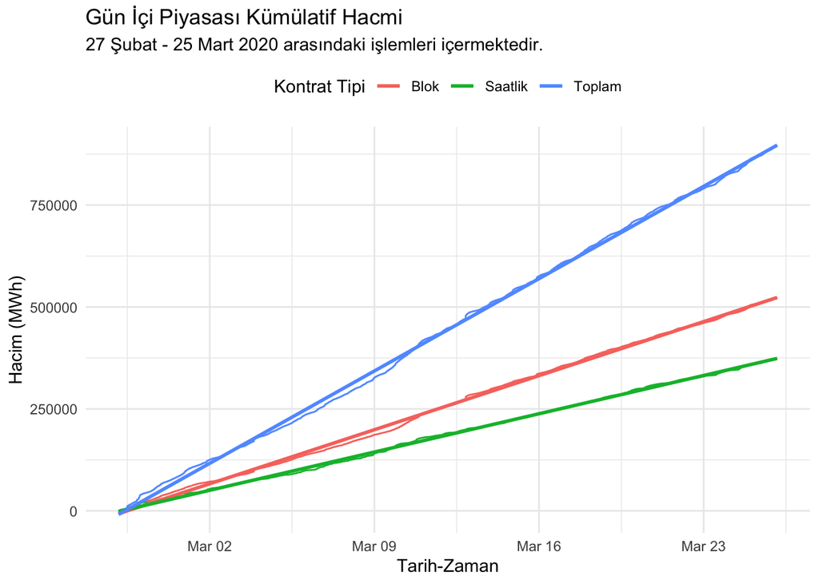

```r
gip_cum <-
  gip_wip %>%
  group_by(dt) %>% # zamana göre gruplayın
  summarise(volume = sum(volume*(1+block_hours))) %>%  # toplam hacim bulun
  ungroup() %>%
  arrange(dt) %>% # zamana göre sıralayın
  mutate(volume = cumsum(volume)) %>% # kümülatif toplam alın
  mutate(contract_type="Total") # toplam değer olduğunu belirtin

gip_cum_2 <-
  gip_wip %>%
  group_by(dt,contract_type) %>%
  summarise(volume = sum(volume*(1+block_hours))) %>%
  ungroup() %>%
  arrange(dt) %>%
  group_by(contract_type) %>%  # kontrat tiplerine göre ayırın
  mutate(volume = cumsum(volume)) %>% ungroup()

bind_rows(gip_cum,gip_cum_2) %>% # iki veri setini satırlardan  birleştirin
  ggplot(.,aes(x=dt,y=volume,color=contract_type)) +
  geom_line() +
  geom_smooth(method = lm, se = FALSE) + #trend çizgilerini ekleyin
  theme_minimal() + # grafiğin elini yüzünü düzenleyin
  labs(
    x="Tarih-Zaman",y="Hacim (MWh)",
    title="Gün İçi Piyasası Kümülatif Hacmi",
    subtitle="27 Şubat - 25 Mart 2020 arasındaki işlemleri içermektedir.",
    color="Kontrat Tipi"
  ) +
  theme(legend.position = "top") +
  scale_color_discrete(labels=c("Blok","Saatlik","Toplam"))
```

Yukarıdaki grafikte basitçe görüldüğü üzere GİP işlem hacimleri dönem dönem değişiklik gösterse de trend çizgilerinden çok uzaklaşmamıştır. Ayrıca blok kontratların saatlik kontratlardan (biraz da hesaplama yöntemimiz sebebiyle) daha fazla hacim gördüğünü söylemek mümkün.

## En Çok İşlem Gören Kontratlar

Sıradaki basit analizimizde en çok işlem gören kontratları sütun grafiğinde göstereceğiz. Önceki analizden farklı olarak listeyi blok kontratların domine etmemesi için kontrat hacmini saatlerle çarpmayacağız.

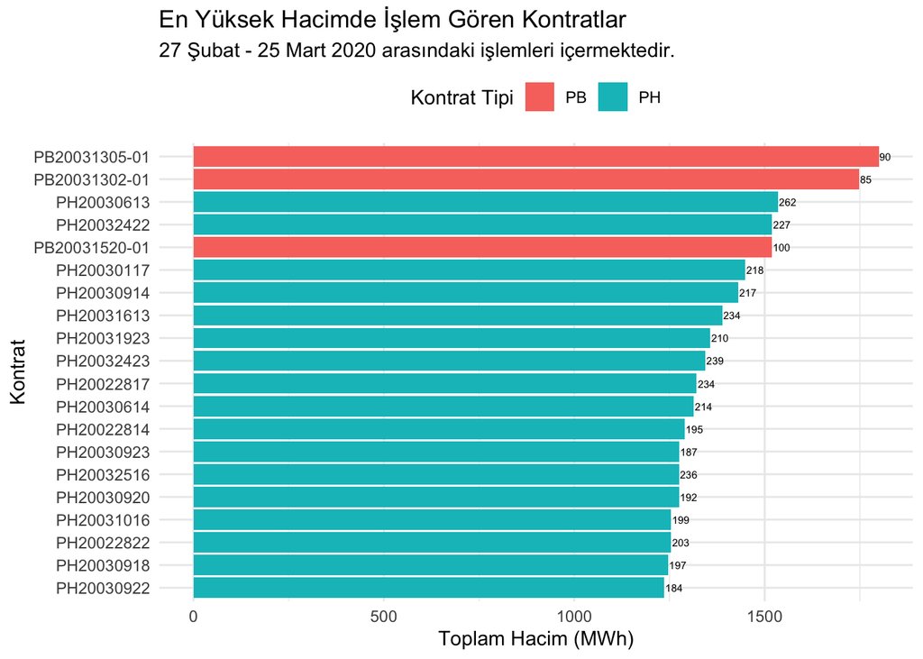

```r
contract_vol_df <-
  gip_wip %>%
  group_by(contract_id,contract_type) %>%
  summarise(count=n(),volume=sum(volume)) %>%
  ungroup() %>%
  arrange(desc(volume)) %>% slice(1:20)

ggplot(contract_vol_df,aes(x=reorder(contract_id,volume),y=volume,fill=contract_type)) + geom_bar(stat="identity") + coord_flip() + theme_minimal() + theme(legend.position = "top") + labs(x="Kontrat",y="Toplam Hacim (MWh)",fill="Kontrat Tipi",title="En Yüksek Hacimde İşlem Gören Kontratlar",subtitle="27 Şubat - 25 Mart 2020 arasındaki işlemleri içermektedir.") +  geom_text(aes(label=paste0(round(count, 0))), position = position_dodge(width = 0.75), hjust=-0.0625,size=2)
```

Yukarıdaki grafikte görülebileceği üzere en yüksek hacimdeki işlemlerin ikisi de blok ve aynı gün olan 13 Mart 2020’ye ait. Diğer işlemlerin yanında daha az kontrat sayısına sahip olmaları işlem başına hacmin de büyük olduğunu gösteriyor.

## Saatlik Kontratların Hacimlerinin Isı Haritası

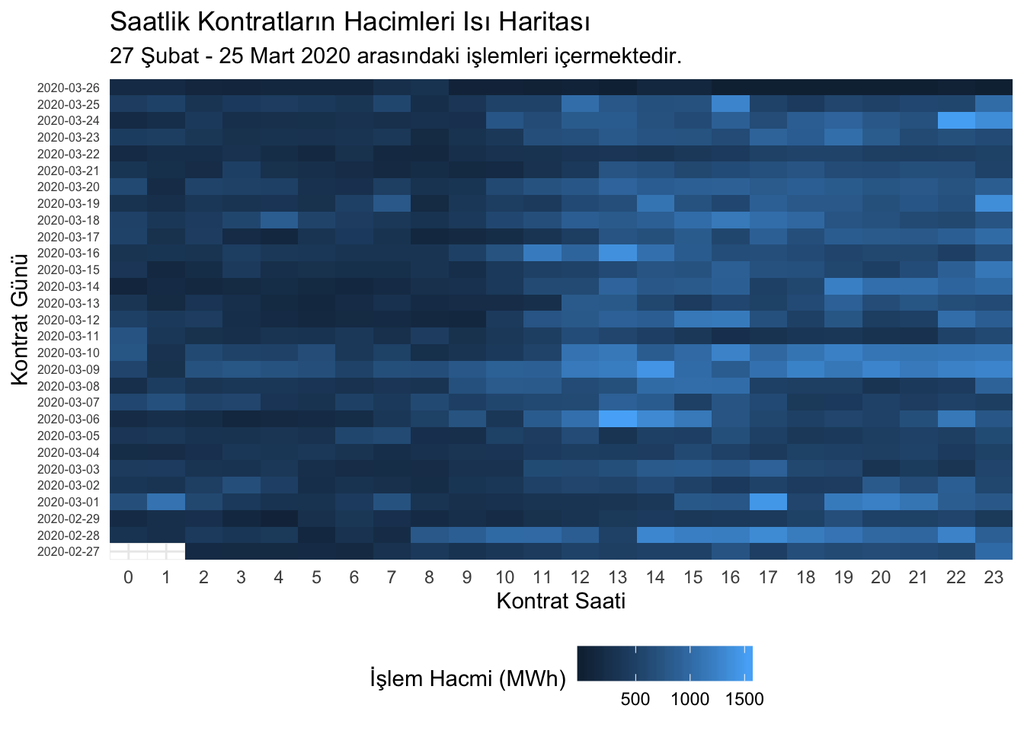

```r
gip_wip %>%
  filter(contract_type == "PH") %>%
group_by(contract_date,contract_start) %>%
summarise(volume=sum(volume)) %>%
ggplot(.,aes(y=contract_date,x=contract_start,fill=volume)) +
  geom_tile() +
  scale_x_continuous(expand=c(0,0),breaks=0:23,labels=0:23) +
  scale_y_date(expand=c(0,0),date_breaks="1 day") +
  theme_minimal() +
  labs(fill = "İşlem Hacmi (MWh)",x="Kontrat Saati",y="Kontrat Günü",title="Saatlik Kontratların Hacimleri Isı Haritası",subtitle="27 Şubat - 25 Mart 2020 arasındaki işlemleri içermektedir.") +
  theme(legend.position = "bottom", axis.text.y = element_text(size=6))
```

Yukarıdaki grafikte görüldüğü üzere saatlik GİP hacmi özellikle 11’den sonraki saatler için daha hareketlidir. Burada ufak bir parantez açarak bir GİP kontratında işlem yapmanın son saati o kontratın geçerli olmaya başladığındaki saatten 60 dakika öncesidir. Örneğin PH2020031508 kontratının kapı kapanış saati 15 Mart 2020 07:00’dır. Dolayısıyla 27 Şubat 2020’deki 00:00 ve 01:00 kontratlarındaki bütün işlemler bir önceki gün yapıldığı için bu veriye dahil değillerdir. Ayrıca ertesi güne ait GİP işlemleri bir önceki gün akşam saatlerinde açılır. 27 Şubat işlemlerinin bir kısmı önceki günün işlem kayıtlarında yer aldığından hacimleri düşük gözüküyor olabilir.

Enerji alanında daha fazla R ve Python dökümanını incelemek için Enerji Analiz GitHub hesabını (https://github.com/acikenerji) ve websitesini (https://acikenerji.github.io/) inceleyebilirsiniz.